# Week 4 -FunctionS Cont.

## FUNCTIONS Cont.

### R (important) built-in functions

There are a lot of built-in functions in R. R matches your input parameters with its function arguments, either by value or by position, then executes the function body. Function arguments can have default values: if you do not specify these arguments, R will take the default value.

Note: It is possible to see the source code of a function by running the name of the function itself in the console.

```r
str
```

```
## function (object, ...)
## UseMethod("str")
## <bytecode: 0x7f853d57c4b0>
## <environment: namespace:utils>
```

#### General Functions, Math Functions, Statistical Functions

##### 1. General Functions

Some examples we have already used are cbind(),rbind(), sort() etc.However, we will cover must-know functions in the following for better analytic implementations.

###### diff() function

Let’s say you will work on time series, you need to stationary the series by taking their lag values. A stationary process allows constant mean, variance and autocorrelation over time. This mainly improves the prediction of a time series. It can be easily done with the function diff(). We can build a random time-series data with a trend and then use the function diff() to stationary the series. The diff() function accepts one argument, a vector, and return suitable lagged and iterated difference.

Note: We often need to create random data, but for learning and comparison we want the numbers to be identical across machines. To ensure we all generate the same data, we use the set.seed() function with arbitrary values of 123. The set.seed() function is generated through the process of pseudorandom number generator that make every modern computers to have the same sequence of numbers. If we don’t use set.seed() function, we will all have different sequence of numbers.

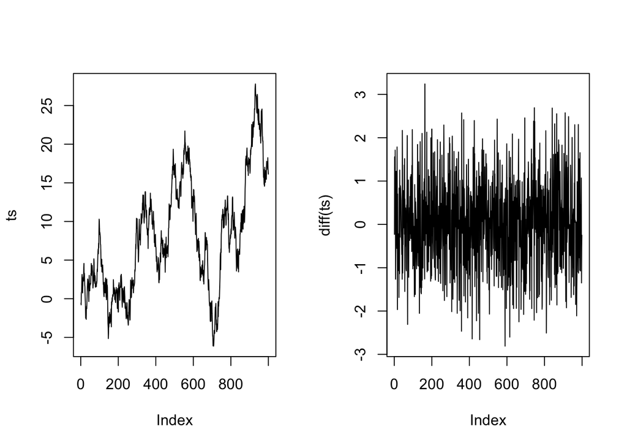

```r
set.seed(123)
## Create the data
x = rnorm(1000)
ts <- cumsum(x)
## Stationary the serie
diff_ts <- diff(ts)
par(mfrow=c(1,2))
## Plot the series
plot(ts, type='l')
plot(diff(ts), type='l')
```

Additional info for plotting with Par:

R makes it easy to combine multiple plots into one overall graph, using either the par( ) or layout( ) function.

With the par( ) function, you can include the option mfrow=c(nrows, ncols) to create a matrix of nrows x ncols plots that are filled in by row. mfcol=c(nrows, ncols) fills in the matrix by columns.

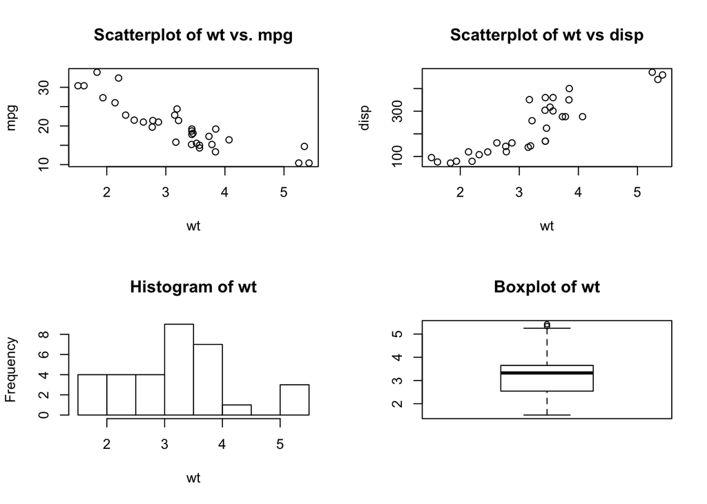

```r
# 4 figures arranged in 2 rows and 2 columns
attach(mtcars)
par(mfrow=c(2,2))
plot(wt,mpg, main="Scatterplot of wt vs. mpg")
plot(wt,disp, main="Scatterplot of wt vs disp")
hist(wt, main="Histogram of wt")
boxplot(wt, main="Boxplot of wt")
```

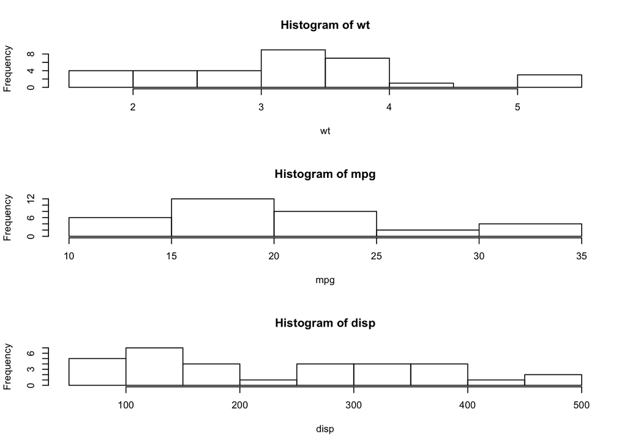

```r
# 3 figures arranged in 3 rows and 1 column
attach(mtcars)
par(mfrow=c(3,1))
hist(wt)
hist(mpg)
hist(disp)
```

##### length() function

The length() function counts the number of rows in a vector. Note that length() returns the number of elements in a vector. If the function is passed into a matrix or a data frame, the number of columns is returned.

```r
length(mtcars)
```

```
## [1] 11
```

How about if I want to return number of rows of mtcars?

#### Math Functions

abs(x) —> takes the absolute value of x

log(x,base=y) —> Takes the logarithm of x with base y; if base is not specified, returns the natural logarithm

exp(x) —-> Returns the exponential of x

sqrt(x) —-> Returns the square root of x

factorial(x) —-> Returns the factorial of x

```r
# sequence of number from 44 to 55 both including incremented by 1
x_vector <- seq(45,55, by = 1)
#logarithm
log(x_vector)
```

```
##  [1] 3.806662 3.828641 3.850148 3.871201 3.891820 3.912023 3.931826
##  [8] 3.951244 3.970292 3.988984 4.007333
```

```r
exp(x_vector)
```

```
##  [1] 3.493427e+19 9.496119e+19 2.581313e+20 7.016736e+20 1.907347e+21
##  [6] 5.184706e+21 1.409349e+22 3.831008e+22 1.041376e+23 2.830753e+23
## [11] 7.694785e+23
```

```r
#sqrt(x_vector)
```

```r
factorial(x_vector)
```

```
##  [1] 1.196222e+56 5.502622e+57 2.586232e+59 1.241392e+61 6.082819e+62
##  [6] 3.041409e+64 1.551119e+66 8.065818e+67 4.274883e+69 2.308437e+71
## [11] 1.269640e+73
```

#### Statistical Functions

mean(x)

median(x)

var(x)

sd(x)

scale(x) —-> standard scores (Z-scores) of x

quantile(x) —-> The quartiles of x

summary(x) —–> summary of x:mean,min,max etc.

```r
mpg <- mtcars$mpg
mpg
```

```
##  [1] 21.0 21.0 22.8 21.4 18.7 18.1 14.3 24.4 22.8 19.2 17.8 16.4 17.3 15.2
## [15] 10.4 10.4 14.7 32.4 30.4 33.9 21.5 15.5 15.2 13.3 19.2 27.3 26.0 30.4
## [29] 15.8 19.7 15.0 21.4
```

```r
# Mean mpg of mtcars dataset
mean(mpg)
```

```
## [1] 20.09062
```

```r
median(mpg)
```

```
## [1] 19.2
```

```r
var(mpg)
```

```
## [1] 36.3241
```

```r
sd(mpg)
```

```
## [1] 6.026948
```

```r
#Standardize vector mpg of mtcars dataset
head(scale(mpg), 5)
```

```
##            [,1]
## [1,]  0.1508848
## [2,]  0.1508848
## [3,]  0.4495434
## [4,]  0.2172534
## [5,] -0.2307345
```

```r
quantile(mpg)
```

```
##     0%    25%    50%    75%   100%
## 10.400 15.425 19.200 22.800 33.900
```

```r
summary(mpg)
```

```
##    Min. 1st Qu.  Median    Mean 3rd Qu.    Max.
##   10.40   15.43   19.20   20.09   22.80   33.90
```

#### Practices

1.Compute the square of integer ‘n’ and call the function and passing value 5

Code Explanation:

rm(square_funtion)  
square_function

#### Scoping in R

In R, the environment is a collection of objects like functions, variables, data frame, etc.

R opens an environment each time Rstudio is prompted.

The top-level environment available is the global environment, called R_GlobalEnv. And we have the local environment.

Difference between global and local environments

```r
y<-8
f<-function(x){
  x+y
}
f(5)
```

```
## [1] 13
```

```r
y
```

```
## [1] 8
```

R also uses the most recent variable definition to pass inside the body of a function

```r
y<-8
f<-function(x){
  y<-5
  x+y
}
f(5)
```

```
## [1] 10
```

#### Example (Normalization Function)

normalize= (x-xmin)/(xmax-xmin) Tibble dataframe

```r
library(tibble)
# Create a data frame
data_frame <- tibble(
  c1 = rnorm(50, 5, 1.5),
  c2 = rnorm(50, 5, 1.5),
  c3 = rnorm(50, 5, 1.5),
)
```

Nominator: : data_frame$c1 -min(data_frame$c1))

Denominator: max(data_frame$c1)-min(data_frame$c1))

Therefore, we can divide them to get the normalized value of column c1: c1_norm should be calculated as follows:

(data_frame$c1 -min(data_frame$c1))/(max(data_frame$c1)-min(data_frame$c1))

```r
#Create c1_norm: rescaling of c1
data_frame$c1_norm <- (data_frame$c1 -min(data_frame$c1))/(max(data_frame$c1)-min(data_frame$c1))
# show the first five values
head(data_frame$c1_norm, 5)
```

```
## [1] 0.2886787 0.2804736 0.4703763 0.4491567 0.0000000
```

We can copy and paste it for C2_norm and C3_norm

```r
data_frame$c2_norm <- (data_frame$c2 - min(data_frame$c2))/(max(data_frame$c2)-min(data_frame$c2))
data_frame$c3_norm <- (data_frame$c3 - min(data_frame$c3))/(max(data_frame$c3)-min(data_frame$c3))
```

Prone error of mundane tasks. In these cases, its good to write a function each time you need to paste same code more than twice. We can arrange the code into a formula and call it whenever it is needed.To write our own function, we need to give:

Name: normalize.

the number of arguments: We only need one argument, which is the column we use in our computation.

The body: this is simply the formula we want to return.

Lets do this step by step:

```r
nominator<-x-min(x)
denominator <- max(x)-min(x)
```

now write the formula

```r
normalize<- nominator/denominator
```

Altogether within a function:

```r
normalize <- function(x){
  # step 1: create the nominator
  nominator <- x-min(x)
  # step 2: create the denominator
  denominator <- max(x)-min(x)
  # step 3: divide nominator by denominator
  normalize <- nominator/denominator
  # return the value
  return(normalize)
}
```

Lets test our function

```r
normalize(data_frame$c1)
```

```
##  [1] 0.2886787 0.2804736 0.4703763 0.4491567 0.0000000 0.6670762 0.5201213
##  [8] 0.9226957 0.6010405 0.3906637 0.9935270 1.0000000 0.2472571 0.5608726
## [15] 0.4344636 0.5084751 0.5159993 0.2392318 0.5267855 0.7987615 0.4432263
## [22] 0.4434425 0.7335992 0.6406569 0.1673950 0.5161877 0.7809786 0.7367032
## [29] 0.5517526 0.6077342 0.2513036 0.5294877 0.2963623 0.3886087 0.6475707
## [36] 0.2624606 0.5233160 0.5533098 0.4839211 0.8123155 0.2837454 0.5863482
## [43] 0.4571924 0.4252497 0.5599546 0.2841072 0.2296527 0.3818332 0.7992279
## [50] 0.4840796
```

```r
data_frame$c1_norm_function <- normalize (data_frame$c1)
data_frame$c2_norm_function <- normalize    (data_frame$c2)
data_frame$c3_norm_function <- normalize    (data_frame$c3)
```

#### Functions with Condition Recap

For instance, in Machine Learning tasks, we need to split the dataset between a train set and a test set. The train set allows the algorithm to learn from the data. In order to test the performance of our model, we can use the test set to return the performance measure. R does not have a function to create two datasets. We can write our own function to do that. Our function takes two arguments and is called split_data(). The idea behind is simple, we multiply the length of dataset (i.e. number of observations) with 0.8. For instance, if we want to split the dataset 80/20, and our dataset contains 100 rows, then our function will multiply 0.8*100 = 80. 80 rows will be selected to become our training data.

Lets use airquality built-in dataset

```r
nrow(airquality)
```

```
## [1] 153
```

split_data <- function(df, train = TRUE)

Arguments:

-df: Define the dataset  
-train: Specify if the function returns the train set or test set. By default, set to TRUE

Our function has two arguments. The arguments train is a Boolean parameter. If it is set to TRUE, our function creates the train dataset, otherwise, it creates the test dataset.

Lets proceed step by step like we did before in normalize() function.

Step 1:

We need to compute the length of the dataset. This is done with the function nrow(). Nrow returns the total number of rows in the dataset. We call the variable length.

```r
length<-nrow(airquality)
length
```

```
## [1] 153
```

Step 2:

We multiply the length by 0.8. It will return the number of rows to select. It should be 153*0.8 = 122.4

```r
total_row <- length*0.8
total_row
```

```
## [1] 122.4
```

We want to select 122 rows among the 153 rows in the airquality dataset. We can create a list containing values from 1 to total_row. We store the result in the variable called split

```r
split <- 1:total_row
split[1:5]
```

```
## [1] 1 2 3 4 5
```

split should choose the first 122 rows from the dataset. For instance, we can see that our variable split gathers the value 1, 2, 3, 4, 5 and so on. These values will be the index when we will select the rows to return.

Step 3:

We need to select the rows in the airquality dataset based on the values stored in the split variable. This is done like this:

```r
train_df <- airquality[split, ]
head(train_df)
```

```
##   Ozone Solar.R Wind Temp Month Day
## 1    41     190  7.4   67     5   1
## 2    36     118  8.0   72     5   2
## 3    12     149 12.6   74     5   3
## 4    18     313 11.5   62     5   4
## 5    NA      NA 14.3   56     5   5
## 6    28      NA 14.9   66     5   6
```

Step 4:

We can create the test dataset by using the remaining rows, 123:153. This is done by using – in front of split.

```r
test_df <- airquality[-split, ]
head(test_df)
```

```
##     Ozone Solar.R Wind Temp Month Day
## 123    85     188  6.3   94     8  31
## 124    96     167  6.9   91     9   1
## 125    78     197  5.1   92     9   2
## 126    73     183  2.8   93     9   3
## 127    91     189  4.6   93     9   4
## 128    47      95  7.4   87     9   5
```

Step 5:

We should create the condition inside the body of the function. Recall, we have an argument train that is a Boolean set to TRUE by default to return the train set. To create the condition, we use the if syntax:

```r
if (train ==TRUE){
    train_df <- airquality[split, ]
      return(train)
  } else {
    test_df <- airquality[-split, ]
      return(test)
  }
```

We now can write our function. We only need to change airquality to df because we want to try our function to any data frame, not only airquality:

```r
split_data <- function(df, train = TRUE){
  length<- nrow(df)
  total_row <- length *0.8
  split <- 1:total_row
  if (train ==TRUE){
    train_df <- df[split, ]
      return(train_df)
  } else {
    test_df <- df[-split, ]
      return(test_df)
  }
}
```

now lets test our function

```r
train<-split_data(airquality, train=TRUE)
dim(train)
```

```
## [1] 122   6
```

```r
test <- split_data(airquality, train = FALSE)
dim(test)
```

```
## [1] 31  6
```

```r
colnames(test)
```

```
## [1] "Ozone"   "Solar.R" "Wind"    "Temp"    "Month"   "Day"
```

```r
typeof(test[0,4])
```

```
## [1] "integer"
```

R provides many functions to examine features of vectors and other objects, for example

class() - what kind of object is it (high-level)?

typeof() - what is the object’s data type (low-level)?

length() - how long is it? What about two dimensional objects?

attributes() - does it have any metadata?

[refer](https://swcarpentry.github.io/r-novice-inflammation/13-supp-data-structures/)

#### Hint for the Homework

colnames(df), typeof(x)

#### More Practice

1.best_practice <- c(“Write”, “programs”, “for”, “people”, “not”, “computers”)

asterisk <- "***" # R interprets a variable with a single value as a vector

Write a function “wrap” which will concantanate first arg in between the second arg into one vector

wrap(best_practice, asterisk)

out: [1] "* * * " “Write” “programs” “for” “people” “not”  
[7] “computers” " * * *"

2.If the variable v refers to a vector, then v[1] is the vector’s first element and v[length(v)] is its last (the function length returns the number of elements in a vector). Write a function called outside that returns a vector made up of just the first and last elements of its input:

dry_principle <- c(“Don’t”, “repeat”, “yourself”, “or”, “others”)

outside(dry_principle)

[1] “Don’t” “others”